# Test Case

### Berkay Gökova

## Business Problem:

Customers, in terms of behavioral shopping patterns, tend to avoid making decisions when exposed to too many buying options. In other words, when a customer is presented with variety of products that exceeds an optimum threshold he/she gets overwhelmed by the number of options. Thus, being able to exploit the recommendation techniques will enable businesses to maximize customer experience. To this end the case study, aims to create a model that is capable of predicting purchase behaviors across differrent business groups.

## Method:

- Using a number of tables that contain customer and product attributes, I have carried out an binary classification modelling session. By assembling some of the useful ML pipeline frameworks I have tested some of the well-known ML algorithms which will be presented later.
- Aside from the genereal information about the customer journey (e.g., product viewing, adding products to basket) on the platform, I have employed **Term Frequency–Inverse Document Frequency Vectorization (TFIDF)** to make full use of the text data by trying to identify the search terms and match them up with the products attributes. This way, I hoped, I could enrich the data at hand to make more accurate predictions.
- Eventually I aimed to evolve the data into a customer-based format with customer demographics presented along with the user-product interactions.

### TFIDF example

**"ananaslı kazak"** term

```
categoryname
Kazak                    1.000000
Tesettür Kazak           0.607630
Büyük Beden Kazak        0.444389
Klasik Ayakkabı               NaN
Pantolon                      NaN
                           ...
Çizim İpi                     NaN
Fotokopi Makinesi             NaN
Motosiklet Pistonları         NaN
Cam Suyu Bidonu               NaN
Silindir Kapakları            NaN
Name: ananaslı kazak, Length: 2487, dtype: float64
```

### Zen Score

This is a self-crafted feature (with a made up name) that aims to catch a non-linear interaction. In the simplest form, this score indicates if there is a specific bugroupname or bugroupnames that the customer keeps viewing or else is he/she actively wandering around the platform without focusing on a product within a day. This will simply tell the extent of which the user focused on specific kinds of products.

**The formula is as follows:**

$(1 - views \div total)^2$

$\text{where views = Number of unique products viewed, total = Number of total views made}$

A number close to 1 means a Zen day (e.g., looking for a specific product) and a number closer to 0 means the user does not look for something specific.

Upon calculating the Zen Scores of each user in a given day, now it's time to calculate the number of Zen days and determine if the target currentbugroupname value is in the visit history of the user.

## Final DataFrame

|  | y | gender | age | tenure | addtobasket_count_basket | productdetailcount_visit | quantity_trx | fav_count_fav | search_count | zen_mean | zen_count |
| --- | --- | --- | --- | --- | --- | --- | --- | --- | --- | --- | --- |
| 0 | 0 | Bayan | 39.000 | 85 | 0.000 | 0.000 | 0.000 | 0.000 | 0.000 | 0.000 | 0.000 |
| 1 | 1 | Bayan | 39.000 | 85 | 0.000 | 33.000 | 0.000 | 0.000 | 0.000 | 0.562 | 7.000 |
| 2 | 0 | Bayan | 39.000 | 85 | 0.000 | 4.000 | 0.000 | 0.000 | 0.000 | 0.503 | 2.000 |
| 3 | 0 | Bayan | 39.000 | 85 | 0.000 | 6.000 | 0.000 | 0.000 | 0.000 | 0.350 | 3.000 |
| 4 | 0 | Bayan | 39.000 | 85 | 0.000 | 1.000 | 0.000 | 0.000 | 0.000 | 0.000 | 1.000 |

### PySpark attempt to work on the 'title' column in df_search_term

```
+--------------------+--------------------+--------------------+--------------------+
|               title|      tokenised_text|                hash|            features|
+--------------------+--------------------+--------------------+--------------------+
|Siyah Kauçuk Taba...|[siyah, kauçuk, t...|(1024,[182,467,56...|(1024,[182,467,56...|
|Kadın Siyah Çizgi...|[kadın, siyah, çi...|(1024,[171,253,36...|(1024,[171,253,36...|
|Color Growth Heal...|[color, growth, h...|(1024,[161,168,18...|(1024,[161,168,18...|
|Kadın  Pamuk Paça...|[kadın, , pamuk, ...|(1024,[253,348,57...|(1024,[253,348,57...|
+--------------------+--------------------+--------------------+--------------------+
only showing top 4 rows
```

## Results:

|  | Model | Accuracy | AUC | Recall | Prec. | F1 | Kappa | MCC | TT (Sec) |
| --- | --- | --- | --- | --- | --- | --- | --- | --- | --- |
| dummy | Dummy Classifier | 0.8855 | 0.5000 | 0.0000 | 0.0000 | 0.0000 | 0.0000 | 0.0000 | 6.2730 |
| xgboost | Extreme Gradient Boosting | 0.8799 | 0.6407 | 0.0962 | 0.4000 | 0.1549 | 0.1157 | 0.1507 | 8.0330 |
| lightgbm | Light Gradient Boosting Machine | 0.8757 | 0.6720 | 0.1347 | 0.3798 | 0.1988 | 0.1477 | 0.1713 | 8.6800 |
| rf | Random Forest Classifier | 0.8491 | 0.6467 | 0.1792 | 0.2652 | 0.2138 | 0.1338 | 0.1370 | 23.4710 |
| catboost | CatBoost Classifier | 0.8457 | 0.6649 | 0.2321 | 0.2858 | 0.2561 | 0.1711 | 0.1723 | 20.0730 |
| et | Extra Trees Classifier | 0.8398 | 0.6535 | 0.2112 | 0.2571 | 0.2319 | 0.1434 | 0.1443 | 33.7610 |
| dt | Decision Tree Classifier | 0.8173 | 0.4876 | 0.2223 | 0.2137 | 0.2179 | 0.1145 | 0.1145 | 9.1590 |
| gbc | Gradient Boosting Classifier | 0.8128 | 0.7086 | 0.3758 | 0.2711 | 0.3149 | 0.2098 | 0.2136 | 52.6240 |
| ada | Ada Boost Classifier | 0.7530 | 0.7135 | 0.5139 | 0.2353 | 0.3227 | 0.1965 | 0.2190 | 16.9160 |
| svm | SVM - Linear Kernel | 0.7467 | 0.0000 | 0.5058 | 0.2293 | 0.3140 | 0.1860 | 0.2084 | 6.5450 |
| lr | Logistic Regression | 0.7119 | 0.7092 | 0.5696 | 0.2146 | 0.3117 | 0.1743 | 0.2076 | 13.1710 |
| ridge | Ridge Classifier | 0.6957 | 0.0000 | 0.5784 | 0.2055 | 0.3033 | 0.1616 | 0.1971 | 5.8380 |
| lda | Linear Discriminant Analysis | 0.6957 | 0.7005 | 0.5784 | 0.2055 | 0.3033 | 0.1616 | 0.1971 | 7.9710 |
| nb | Naive Bayes | 0.1594 | 0.6849 | 0.9601 | 0.1162 | 0.2074 | 0.0039 | 0.0220 | 6.3410 |
| qda | Quadratic Discriminant Analysis | 0.1146 | 0.5000 | 0.9999 | 0.1145 | 0.2055 | 0.0000 | 0.0005 | 7.0980 |

For obvious reasons the accuracy metric is quite deceptive in evaluating the models due to the imbalance between target values. As can be seen from the table, although some of them show better improvements in precision, all of them fail in showing satisfactory results both in f1 score and recall. In addition, the raw probability values of the test output are close to 0.5 which means that the model is not confident with the predictions. The performance of the model is effected by the TFIDF model of course as it left so many search terms unmatched so one solution could be developing a better performing text mining model.

Another and probably more important aspect is to feed non-linear interactions between features. One example can be searching density or in other words measuring the frequency of a user's searching action and calculating a density ratio across all the business group names. However this approach would work better if the date column in search terms dataset would have a higher granularity.

All in all, the model requires a neat work when it comes to feature engineering. This will require great deal of data manipulation and domain knowledge. This pipeline is designed to ease that process and to experiment with novel approaches for coming up with better results.

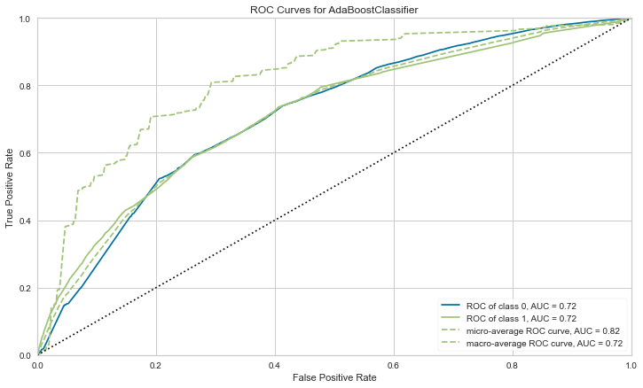

**AUC** plot indicates a decent curve but it requires more in-depth examination

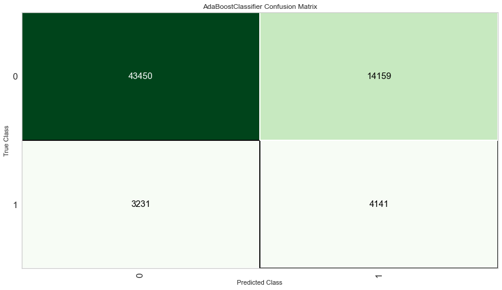

Confusion matrix presents does not present a promising result.

## MLFlow view

[figure not shown]

## Selected Model: Ada Boost

Seemingly best possible option in the table is Ada Boost as it has relatively decent accuracy and recall values. However the precision value is troublesome. Here you can see the 10-Fold Cross Validation values for hyperparameter tuned Ada Boost Model.

| Fold | Accuracy | AUC | Recall | Prec. | F1 | Kappa | MCC |
| --- | --- | --- | --- | --- | --- | --- | --- |
| 0 | 0.7454 | 0.7133 | 0.5248 | 0.2309 | 0.3207 | 0.1922 | 0.2168 |
| 1 | 0.7472 | 0.7132 | 0.5230 | 0.2320 | 0.3215 | 0.1936 | 0.2177 |
| 2 | 0.7529 | 0.7250 | 0.5323 | 0.2395 | 0.3304 | 0.2048 | 0.2294 |
| 3 | 0.7539 | 0.7110 | 0.4948 | 0.2313 | 0.3152 | 0.1886 | 0.2089 |
| 4 | 0.7573 | 0.7077 | 0.5063 | 0.2374 | 0.3233 | 0.1983 | 0.2195 |
| 5 | 0.7570 | 0.7204 | 0.5127 | 0.2387 | 0.3257 | 0.2008 | 0.2227 |
| 6 | 0.7519 | 0.7114 | 0.5259 | 0.2370 | 0.3268 | 0.2006 | 0.2246 |
| 7 | 0.7502 | 0.7070 | 0.5130 | 0.2325 | 0.3200 | 0.1927 | 0.2154 |
| 8 | 0.7475 | 0.7102 | 0.5118 | 0.2297 | 0.3171 | 0.1888 | 0.2117 |
| 9 | 0.7670 | 0.7164 | 0.4942 | 0.2442 | 0.3269 | 0.2051 | 0.2237 |
| Mean | 0.7530 | 0.7135 | 0.5139 | 0.2353 | 0.3227 | 0.1965 | 0.2190 |
| Std | 0.0060 | 0.0054 | 0.0122 | 0.0045 | 0.0045 | 0.0059 | 0.0059 |

## Challenges:

**1-** Firstly, the data was huge in terms of size, especially for text-mining operations. I wanted use different methods such as TFIDF, word2vec etc. for the product descriptions column. However, the output matrices were made it impossible for my computer to process them. As a solution, I tried to use PySpark framework for distributing the computational load but I failed due to using single node (my local PC) for a huge dataset. I would love to see it work with multiple nodes.

**2-** I was given 9 different csv files which I thought would be programmatically exhaustive to be merged on Python. Therefore I decided to use SQLite Database on which I could write queries to join multiple tables. For this side I have written a local library that I could manage migrating, accessing, controling an SQL database within a jupyter notebook environment. However SQLite query responses was unexpectedly poor so that I decided to use it for small operations.

**3-** The given data required some cleaning operations as it had a couple of fields that were provided by humans (i.e., age values provided by customers had values like “2019„). I have let PyCaret to take care of the imputation phase but I wonder if KNN Imputer would help increasing performance. Other than that, time granularity of the datasets vary which makes it somewhat hard to come up with an idea to include data details.

## Bonus:

In the project I have used Ploomber framework to orchestrate every step in an automated fashion. This means that the project can be reproduced by installing MLFlow and Ploomber frameworks described in the **Ploomber README** file inside the root directory, in case you want to try.

## Closing Thoughts

I am aware that the models could have performed better with some feature engineering touch. I might have come short in terms of applying domain knowledge to the feature engineering side, due to my lack of experience in e-commerce. However I think that I can come up with a better model as I get more and more experience. Nonetheless I am quite happy with where this project going. Because I wanted this project to be something that can be improved drastically in future. To that end I structured this whole project as an end-to-end pipeline which is the reason why I have integrated Ploomber, PyCaret and MLFlow to the project. So that I can do experiments and figure out the essence of the recommender systems in e-commerce. I have spent a significant amount of time to integrate PySpark in the project which did not end as hoped but I learned a lot even when failing. Overall I have tried to accomplished so much in so little time and I enjoyed the journey.